# presentation

2022-10-12

## Attaching the required libraries \<br>

## Step1 (Data exploring and EDA):

## We will start by importing the dataset

## We started by exploring our dataset

```
## Rows: 271,116
## Columns: 15
## $ ID     <int> 1, 2, 3, 4, 5, 5, 5, 5, 5, 5, 6, 6, 6, 6, 6, 6, 6, 6, 7, 7, 7, …
## $ Name   <chr> "A Dijiang", "A Lamusi", "Gunnar Nielsen Aaby", "Edgar Lindenau…
## $ Sex    <chr> "M", "M", "M", "M", "F", "F", "F", "F", "F", "F", "M", "M", "M"…
## $ Age    <int> 24, 23, 24, 34, 21, 21, 25, 25, 27, 27, 31, 31, 31, 31, 33, 33,…
## $ Height <int> 180, 170, NA, NA, 185, 185, 185, 185, 185, 185, 188, 188, 188, …
## $ Weight <dbl> 80, 60, NA, NA, 82, 82, 82, 82, 82, 82, 75, 75, 75, 75, 75, 75,…
## $ Team   <chr> "China", "China", "Denmark", "Denmark/Sweden", "Netherlands", "…
## $ NOC    <chr> "CHN", "CHN", "DEN", "DEN", "NED", "NED", "NED", "NED", "NED", …
## $ Games  <chr> "1992 Summer", "2012 Summer", "1920 Summer", "1900 Summer", "19…
## $ Year   <int> 1992, 2012, 1920, 1900, 1988, 1988, 1992, 1992, 1994, 1994, 199…
## $ Season <chr> "Summer", "Summer", "Summer", "Summer", "Winter", "Winter", "Wi…
## $ City   <chr> "Barcelona", "London", "Antwerpen", "Paris", "Calgary", "Calgar…
## $ Sport  <chr> "Basketball", "Judo", "Football", "Tug-Of-War", "Speed Skating"…
## $ Event  <chr> "Basketball Men's Basketball", "Judo Men's Extra-Lightweight", …
## $ Medal  <chr> NA, NA, NA, "Gold", NA, NA, NA, NA, NA, NA, NA, NA, NA, NA, NA,…
```

Data summary

| Name | olympic |
| --- | --- |
| Number of rows | 271116 |
| Number of columns | 15 |
| _______________________ |  |
| Column type frequency: |  |
| character | 10 |
| numeric | 5 |
| ________________________ |  |
| Group variables | None |

**Variable type: character**

| skim_variable | n_missing | complete_rate | min | max | empty | n_unique | whitespace |
| --- | --- | --- | --- | --- | --- | --- | --- |
| Name | 0 | 1.00 | 2 | 108 | 0 | 134732 | 0 |
| Sex | 0 | 1.00 | 1 | 1 | 0 | 2 | 0 |
| Team | 0 | 1.00 | 2 | 47 | 0 | 1184 | 0 |
| NOC | 0 | 1.00 | 3 | 3 | 0 | 230 | 0 |
| Games | 0 | 1.00 | 11 | 11 | 0 | 51 | 0 |
| Season | 0 | 1.00 | 6 | 6 | 0 | 2 | 0 |
| City | 0 | 1.00 | 4 | 22 | 0 | 42 | 0 |
| Sport | 0 | 1.00 | 4 | 25 | 0 | 66 | 0 |
| Event | 0 | 1.00 | 15 | 85 | 0 | 765 | 0 |
| Medal | 231333 | 0.15 | 4 | 6 | 0 | 3 | 0 |

**Variable type: numeric**

| skim_variable | n_missing | complete_rate | mean | sd | p0 | p25 | p50 | p75 | p100 | hist |
| --- | --- | --- | --- | --- | --- | --- | --- | --- | --- | --- |
| ID | 0 | 1.00 | 68248.95 | 39022.29 | 1 | 34643 | 68205 | 102097.2 | 135571 | ▇▇▇▇▇ |
| Age | 9474 | 0.97 | 25.56 | 6.39 | 10 | 21 | 24 | 28.0 | 97 | ▇▃▁▁▁ |
| Height | 60171 | 0.78 | 175.34 | 10.52 | 127 | 168 | 175 | 183.0 | 226 | ▁▂▇▂▁ |
| Weight | 62875 | 0.77 | 70.70 | 14.35 | 25 | 60 | 70 | 79.0 | 214 | ▃▇▁▁▁ |
| Year | 0 | 1.00 | 1978.38 | 29.88 | 1896 | 1960 | 1988 | 2002.0 | 2016 | ▁▂▃▆▇ |

```
##        ID             Name               Sex                 Age
##  Min.   :     1   Length:271116      Length:271116      Min.   :10.00
##  1st Qu.: 34643   Class :character   Class :character   1st Qu.:21.00
##  Median : 68205   Mode  :character   Mode  :character   Median :24.00
##  Mean   : 68249                                         Mean   :25.56
##  3rd Qu.:102097                                         3rd Qu.:28.00
##  Max.   :135571                                         Max.   :97.00
##                                                         NA's   :9474
##      Height          Weight          Team               NOC
##  Min.   :127.0   Min.   : 25.0   Length:271116      Length:271116
##  1st Qu.:168.0   1st Qu.: 60.0   Class :character   Class :character
##  Median :175.0   Median : 70.0   Mode  :character   Mode  :character
##  Mean   :175.3   Mean   : 70.7
##  3rd Qu.:183.0   3rd Qu.: 79.0
##  Max.   :226.0   Max.   :214.0
##  NA's   :60171   NA's   :62875
##     Games                Year         Season              City
##  Length:271116      Min.   :1896   Length:271116      Length:271116
##  Class :character   1st Qu.:1960   Class :character   Class :character
##  Mode  :character   Median :1988   Mode  :character   Mode  :character
##                     Mean   :1978
##                     3rd Qu.:2002
##                     Max.   :2016
##
##     Sport              Event              Medal
##  Length:271116      Length:271116      Length:271116
##  Class :character   Class :character   Class :character
##  Mode  :character   Mode  :character   Mode  :character
##
##
##
##
```

```
## 'data.frame':    271116 obs. of  15 variables:
##  $ ID    : int  1 2 3 4 5 5 5 5 5 5 ...
##  $ Name  : chr  "A Dijiang" "A Lamusi" "Gunnar Nielsen Aaby" "Edgar Lindenau Aabye" ...
##  $ Sex   : chr  "M" "M" "M" "M" ...
##  $ Age   : int  24 23 24 34 21 21 25 25 27 27 ...
##  $ Height: int  180 170 NA NA 185 185 185 185 185 185 ...
##  $ Weight: num  80 60 NA NA 82 82 82 82 82 82 ...
##  $ Team  : chr  "China" "China" "Denmark" "Denmark/Sweden" ...
##  $ NOC   : chr  "CHN" "CHN" "DEN" "DEN" ...
##  $ Games : chr  "1992 Summer" "2012 Summer" "1920 Summer" "1900 Summer" ...
##  $ Year  : int  1992 2012 1920 1900 1988 1988 1992 1992 1994 1994 ...
##  $ Season: chr  "Summer" "Summer" "Summer" "Summer" ...
##  $ City  : chr  "Barcelona" "London" "Antwerpen" "Paris" ...
##  $ Sport : chr  "Basketball" "Judo" "Football" "Tug-Of-War" ...
##  $ Event : chr  "Basketball Men's Basketball" "Judo Men's Extra-Lightweight" "Football Men's Football" "Tug-Of-War Men's Tug-Of-War" ...
##  $ Medal : chr  NA NA NA "Gold" ...
```

## Step2 (Data cleaning):

### We figured out that we need to do column name cleaning using janitor package

## Then, modified the data type to be factor

## Our dataset has missing values in the medal column. Thus, we decided to deal with them

```
## [1] 363853
```

```
## # A tibble: 4 × 2
## # Groups:   olympic_df$medal [4]
##   `olympic_df$medal`      n
##   <chr>               <int>
## 1 Bronze              13295
## 2 Gold                13372
## 3 Silver              13116
## 4 <NA>               231333
```

```
##
##  Bronze    Gold Not win  Silver
##   13295   13372  231333   13116
```

## Step 3 (find answers to our questions):

```
##  [1] Basketball                Judo
##  [3] Football                  Tug-Of-War
##  [5] Speed Skating             Cross Country Skiing
##  [7] Athletics                 Ice Hockey
##  [9] Swimming                  Badminton
## [11] Sailing                   Biathlon
## [13] Gymnastics                Art Competitions
## [15] Alpine Skiing             Handball
## [17] Weightlifting             Wrestling
## [19] Luge                      Water Polo
## [21] Hockey                    Rowing
## [23] Bobsleigh                 Fencing
## [25] Equestrianism             Shooting
## [27] Boxing                    Taekwondo
## [29] Cycling                   Diving
```

[output cut: 19 more lines]

```
## [1] 66
```

### Q2: What is the total number of sporting events (for winter and summer)?

```
## # A tibble: 51 × 4
## # Groups:   year [35]
##     year season Athletes Events
##    <int> <fct>     <int>  <int>
##  1  1896 Summer      176     43
##  2  1900 Summer     1224     90
##  3  1904 Summer      650     95
##  4  1906 Summer      841     74
##  5  1908 Summer     2024    109
##  6  1912 Summer     2409    107
##  7  1920 Summer     2676    158
##  8  1924 Summer     3256    131
##  9  1924 Winter      313     17
## 10  1928 Summer     3247    122
## # … with 41 more rows
```

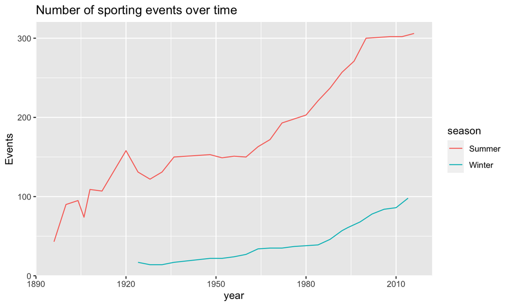

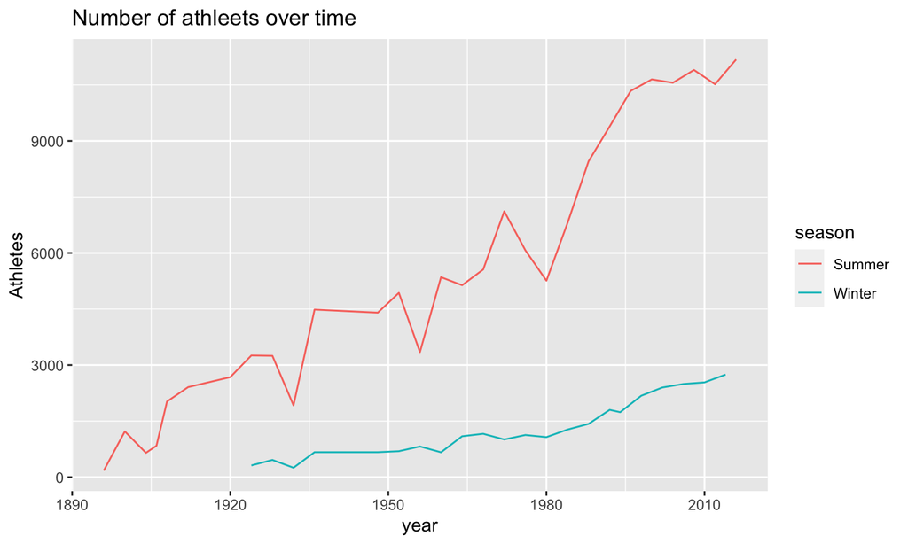

### Q3: What is the total number of medals won by each country?

[output not shown]

```
## # A tibble: 362 × 3
## # Groups:   noc [149]
##    noc   medal  Total
##    <fct> <fct>  <int>
##  1 AFG   Bronze     2
##  2 AHO   Silver     1
##  3 ALG   Bronze     8
##  4 ALG   Gold       5
##  5 ALG   Silver     4
##  6 ANZ   Bronze     5
##  7 ANZ   Gold      20
##  8 ANZ   Silver     4
##  9 ARG   Bronze    91
## 10 ARG   Gold      91
## # … with 352 more rows
```

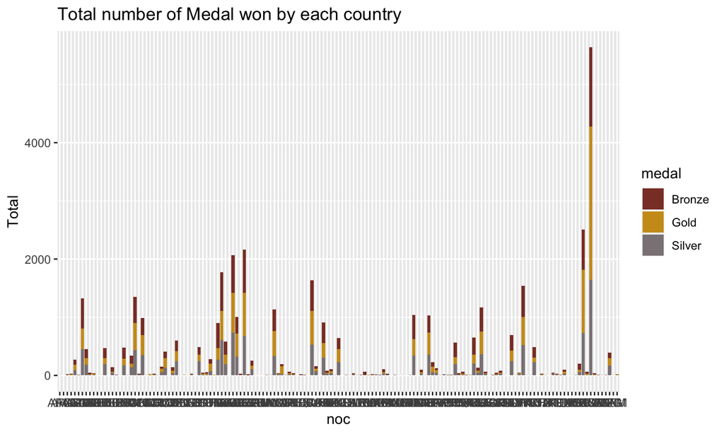

```
## # A tibble: 498 × 2
##    team                         Total
##    <chr>                        <int>
##  1 A North American Team            4
##  2 Afghanistan                      2
##  3 Algeria                         17
##  4 Ali-Baba II                      5
##  5 Amateur Athletic Association     5
##  6 Amstel Amsterdam                 4
##  7 Ancora                           4
##  8 Angelita                        12
##  9 Antwerpia V                      5
## 10 Aphrodite                        3
## # … with 488 more rows
```

### Q4: Who are the top 3 countries that have the most number of participants over the years and how do we compare them over the years?

```
##
##   USA   FRA   GBR   ITA   GER
## 18853 12758 12256 10715  9830
```

#### United States:

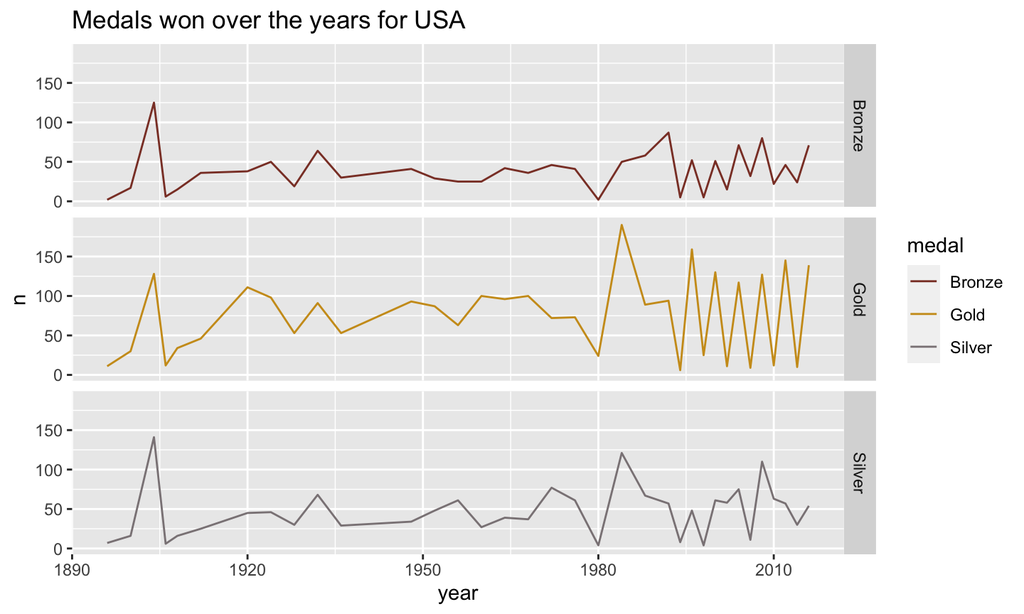

#### France

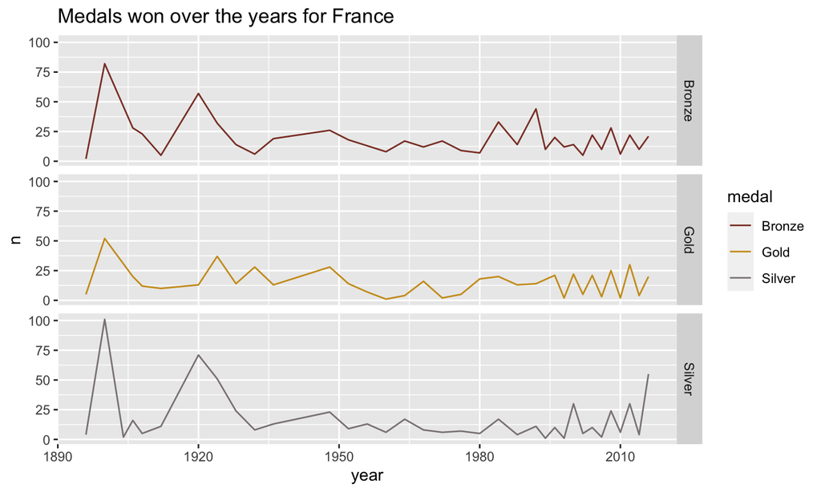

#### United Kingdom:

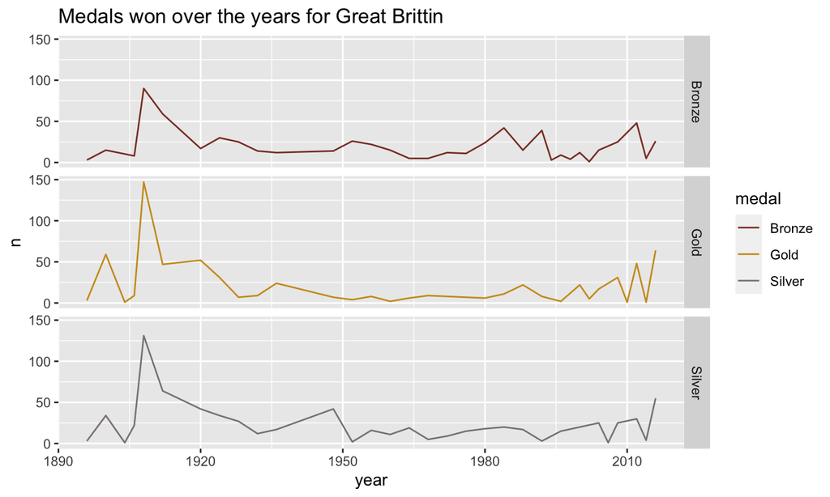

### Q5: What is the percentage of the distribution of male and female athletes throughout the years of Olympic history?

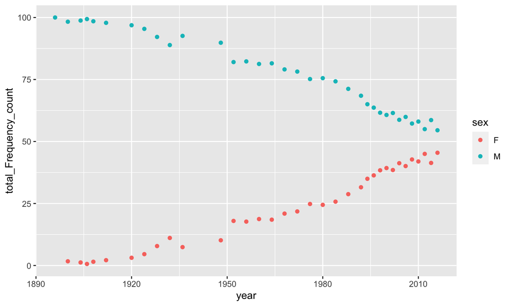

### Q6: How many male and females participated in the Olympics?

```
## # A tibble: 2 × 2
##   sex    count
##   <fct>  <int>
## 1 F      33981
## 2 M     101590
```

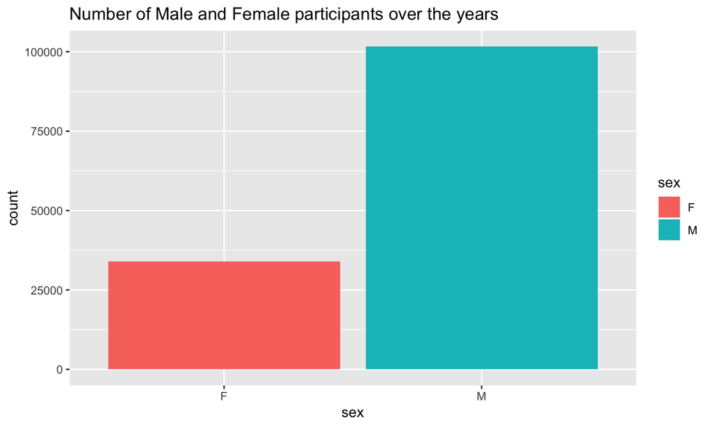

### Q7: Can we comparing men and women winners over the years for summer and winter?

#### Summer:

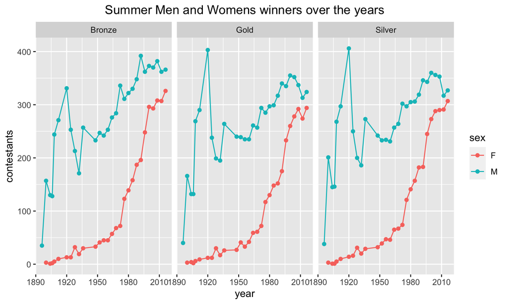

#### Winter:

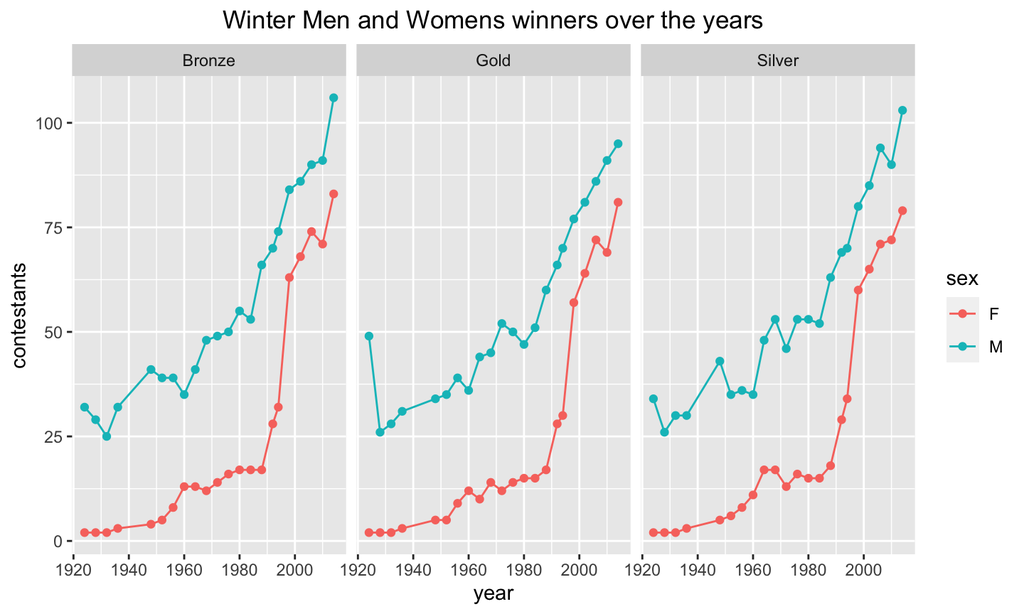

### Q8: How many medal have been won by male and female?

```
## # A tibble: 8 × 3
## # Groups:   sex, medal [8]
##   sex   medal        n
##   <fct> <fct>    <int>
## 1 F     Bronze    3771
## 2 F     Gold      3747
## 3 F     Not win  63269
## 4 F     Silver    3735
## 5 M     Bronze    9524
## 6 M     Gold      9625
## 7 M     Not win 168064
## 8 M     Silver    9381
```

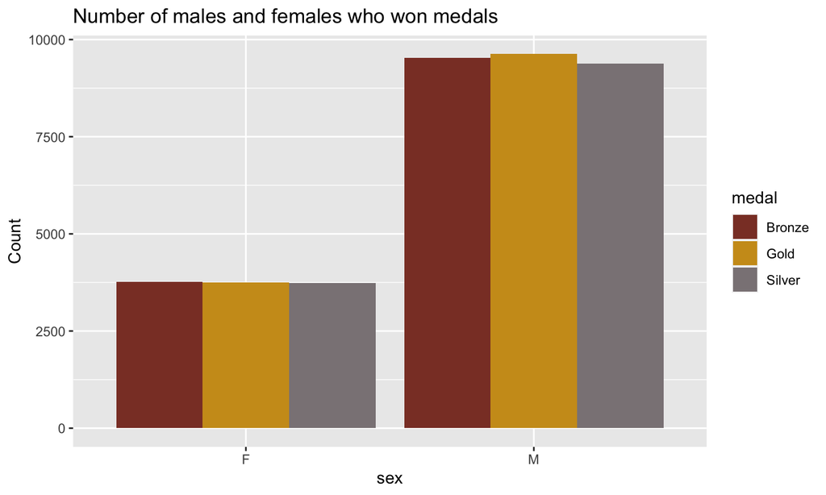

### Q9: What is the most productive age for both male and female athletes in all sorts of sports?

[output not shown]

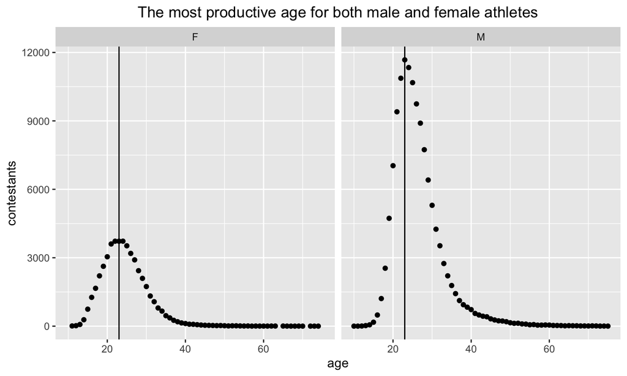

### Q10: Is there a relation between athletes’ gender and their winning to their olympic game?

[output not shown]

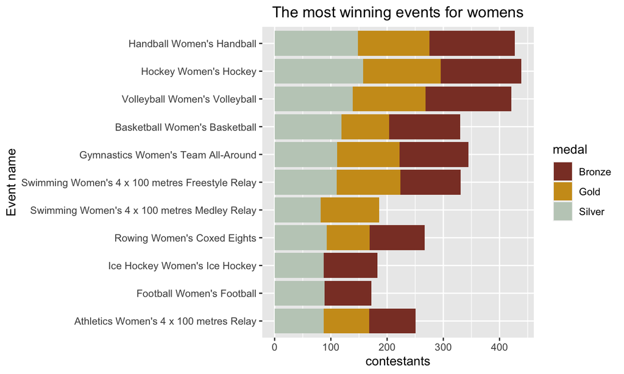

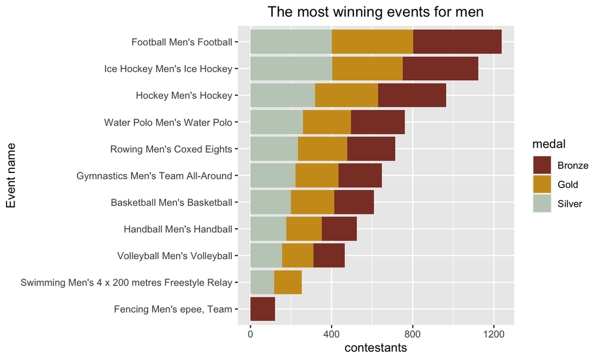

## Step 4 (Hypothesis testing questions):

### Women growth since they joined the olympics

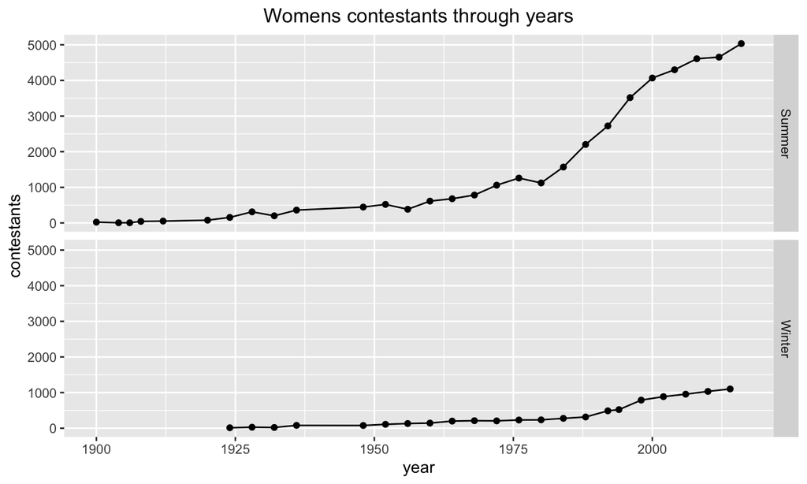

### Men growth vs. women growth

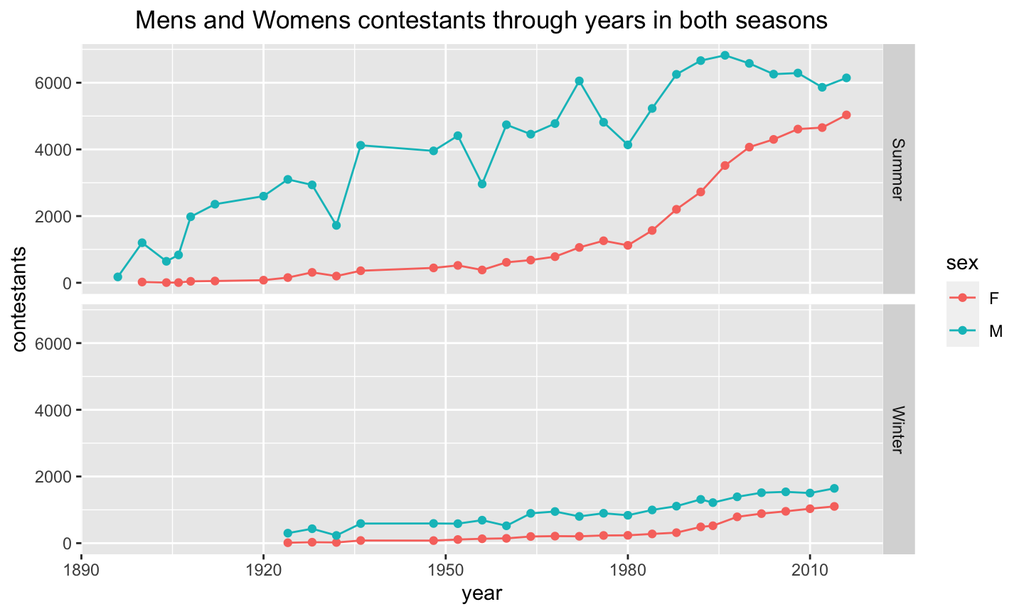